# Change in Competition Due to a Merger: Logit

## Logit

The logit model merger simulation works by using a regression to estimate a demand curve for the market. Then using the price coefficients we estimate cross price elasticy with other vehicles in the market. Then we think of each firms profit maximizing strategy and simulate a merger by combining two of the firms in the market.

```r
cars <- haven::read_dta("cars_2004.dta")
```

## Build Data Set

```r
#Add market size column and assign corresponding year's value
cars <- cbind.data.frame(cars,matrix(,nrow = 284, ncol = 1,dimnames=list(c(),c("TAM"))))

cars$TAM[which(cars$year==2003)] <- 111278000
cars$TAM[which(cars$year==2004)] <- 112000000
cars$TAM[which(cars$year==2005)] <- 113343000
cars$TAM[which(cars$year==2006)] <- 114384000

#generate market share
cars$Marketshare <- cars$Tvolume / cars$TAM

#generate the total sale volume within a market
cars$Total.inside <- with(cars, ave(Tvolume, year, FUN=sum))

#generate the outside share for each market
cars$Outside.Share <- 1 - (cars$Total.inside/cars$TAM)

#generate the utility variable
cars$u <- log(cars$Marketshare) - log(cars$Outside.Share)

#total product characteristics
market.dpm <- with(cars, ave(dpm, year, FUN=sum))
market.length <- with(cars, ave(length, year, FUN=sum))
market.hpw <- with(cars, ave(hpw, year, FUN=sum))
cars <- cbind.data.frame(cars, market.dpm , market.length , market.hpw)

#number of competitors
cars$temp <- 1
cars$total.comp <- with(cars, ave(temp, year, FUN=sum))

#create IV's
cars$IV.dpm <- (cars$market.dpm - cars$dpm)/(cars$total.comp - 1)
cars$IV.length <- (cars$market.length - cars$length)/ (cars$total.comp -1)
cars$IV.hpw <- (cars$market.hpw - cars$hpw) / (cars$total.comp - 1)
```

Estimate logit demand model where each year is treated as a separate market.

```r
#Run 2sls with
library("ivreg")
cars$year<-factor(cars$year, levels=c("2004","2003","2005","2006"))
cars$mfrid<-factor(cars$mfrid)
cars$mfrid<-relevel(cars$mfrid,ref=12)

IV.reg <- ivreg(u ~ dpm + length + hpw + year + mfrid | price | IV.dpm + IV.length +IV.hpw, data = cars )
alpha <- IV.reg$coefficients[2]
paste("Note that our coefficient for the IV estimate of price is",round(alpha,3)," ,rounded to the third decimal place")
```

[1] “Note that our coefficient for the IV estimate of price is -0.155 ,rounded to the third decimal place”

```r
stargazer(IV.reg,type="html",title="IV regression",no.space=TRUE)
```

**IV regression**

|  | *Dependent variable:* |
| --- | --- |
|  | u |
| price | -0.155 |
|  | (0.198) |
| dpm | -37.003 |
|  | (55.860) |
| length | 0.039*** |
|  | (0.012) |
| hpw | 0.036 |
|  | (0.059) |
| year2003 | -3.321*** |
|  | (0.465) |
| year2005 | -1.813*** |
|  | (0.494) |
| year2006 | -6.340*** |
|  | (0.411) |
| mfrid1 | 2.924 |
|  | (2.233) |
| mfrid2 | 0.222 |
|  | (1.192) |
| mfrid3 | 0.170 |
|  | (0.859) |
| mfrid4 | 0.645 |
|  | (0.497) |
| mfrid5 | 0.775 |
|  | (0.646) |
| mfrid6 | 0.717 |
|  | (0.538) |
| mfrid7 | 1.908 |
|  | (1.882) |
| mfrid8 | 0.135 |
|  | (0.668) |
| mfrid9 | -1.354 |
|  | (2.931) |
| mfrid10 | 4.044 |
|  | (3.735) |
| mfrid11 | 0.349 |
|  | (0.569) |
| mfrid13 | 0.688 |
|  | (0.520) |
| Constant | -13.986*** |
|  | (1.843) |
| Observations | 284 |
| R<sup>2</sup> | 0.601 |
| Adjusted R<sup>2</sup> | 0.572 |
| Residual Std. Error | 1.656 (df = 264) |
| *Note:* | p<0.1; p<0.05; p<0.01 |

- Estimate own and cross price elasticities

```r
#keep 2004
cars2004 <- cars[which(cars$year == 2004),]

#generate elastic matrix for cross and own price elasticities
elastic.matrix <- matrix(0, nrow(cars2004), nrow(cars2004), dimnames=list(as.character(cars2004$model),as.character(cars2004$model)))
for (i in 1:nrow(cars2004)) {
  for (j in 1:nrow(cars2004)) {
    if (i==j) {
      elastic.matrix[i,j] <- alpha*cars2004$price[j]*(1- cars2004$Marketshare[i])
    } else{
      elastic.matrix[i,j] <- - alpha*cars2004$Marketshare[i]*cars2004$price[i]
    }
  }
}

Q3 <- data.frame(Camry=elastic.matrix[,'CAMRY'], Civic=elastic.matrix[,"CIVIC"], Mazda.3=elastic.matrix[,'3'], AUDI.A6=elastic.matrix[,"AUDI A6"],row.names=as.character(cars2004$model))

stargazer(Q3,type="html",title="Specific models",summary=FALSE)
```

**Specific models**

|  | Camry | Civic | Mazda.3 | AUDI.A6 |
| --- | --- | --- | --- | --- |
| BMW 6 SERIES | 0.001 | 0.001 | 0.001 | 0.001 |
| BMW 5 SERIES | 0.003 | 0.003 | 0.003 | 0.003 |
| BMW X3 | 0.001 | 0.001 | 0.001 | 0.001 |
| BMW X5 | 0.002 | 0.002 | 0.002 | 0.002 |
| MINI COOPER | 0.001 | 0.001 | 0.001 | 0.001 |
| BMW Z4 | 0.001 | 0.001 | 0.001 | 0.001 |
| BMW 7 SERIES | 0.002 | 0.002 | 0.002 | 0.002 |
| BMW 3 SERIES | 0.005 | 0.005 | 0.005 | 0.005 |
| LEGACY | 0.002 | 0.002 | 0.002 | 0.002 |
| FORESTER | 0.002 | 0.002 | 0.002 | 0.002 |
| IMPREZA | 0.001 | 0.001 | 0.001 | 0.001 |
| MDX | 0.003 | 0.003 | 0.003 | 0.003 |
| CIVIC HYBRID | 0.001 | 0.001 | 0.001 | 0.001 |
| ACCORD | 0.011 | 0.011 | 0.011 | 0.011 |
| INSIGHT | 0.00002 | 0.00002 | 0.00002 | 0.00002 |
| CIVIC | 0.005 | -2.660 | 0.005 | 0.005 |
| TSX | 0.001 | 0.001 | 0.001 | 0.001 |
| RL | 0.0003 | 0.0003 | 0.0003 | 0.0003 |
| TL | 0.003 | 0.003 | 0.003 | 0.003 |
| S2000 | 0.0003 | 0.0003 | 0.0003 | 0.0003 |
| ELEMENT | 0.001 | 0.001 | 0.001 | 0.001 |
| RSX | 0.001 | 0.001 | 0.001 | 0.001 |
| PILOT | 0.005 | 0.005 | 0.005 | 0.005 |
| TIBURON | 0.0004 | 0.0004 | 0.0004 | 0.0004 |
| ELANTRA | 0.002 | 0.002 | 0.002 | 0.002 |
| XG350 | 0.001 | 0.001 | 0.001 | 0.001 |
| ACCENT | 0.001 | 0.001 | 0.001 | 0.001 |
| SANTA FE | 0.003 | 0.003 | 0.003 | 0.003 |
| SONATA | 0.002 | 0.002 | 0.002 | 0.002 |
| RIO | 0.001 | 0.001 | 0.001 | 0.001 |

[output cut: 70 more lines]

Calculate marginal cost and lerner index for each car.

```r
ownership.Matrix <-Partial.matrix<- matrix(0, nrow(cars2004), nrow(cars2004))

for (i in 1:nrow(cars2004)) {
  for (j in 1:nrow(cars2004)) {
    if (cars2004$mfrid[i]==cars2004$mfrid[j]) {
      ownership.Matrix[i,j]=1
    }
  }
}

for (i in 1:nrow(cars2004)) {
  for (j in 1:nrow(cars2004)) {
    if (i==j) {
      Partial.matrix[i,j] <- alpha*cars2004$Marketshare[i]*(1- cars2004$Marketshare[i])
    } else{
      Partial.matrix[i,j] <- - alpha*cars2004$Marketshare[i]*cars2004$Marketshare[j]
    }
  }
}
mul <- ownership.Matrix * Partial.matrix
mul.inverse <- solve(mul)

#marginal Cost

Marginal.cost <- cars2004$price + (mul.inverse %*% cars2004$Marketshare)
Marginal.cost <- as.data.frame(Marginal.cost)
colnames(Marginal.cost) <- "Marginal.cost"
Lerner.Index <- matrix(, nrow = 100, ncol = 1)
colnames(Lerner.Index) <- "Lerner.Index"
for (i in 1:100) {
  Lerner.Index[i,1] <- (cars2004$price[i] - Marginal.cost[i,1]) / cars2004$price[i]
}
```

[output not shown]

[output not shown]

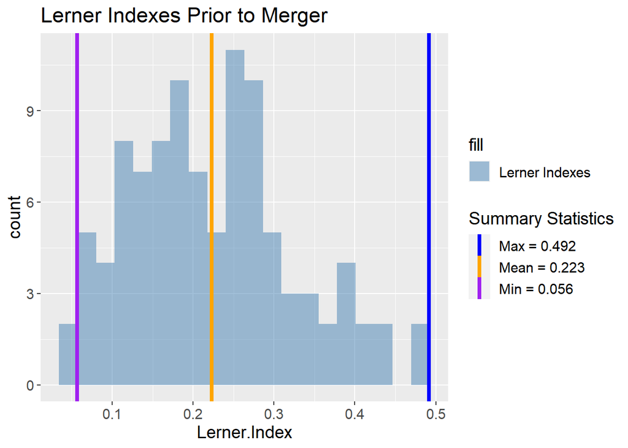

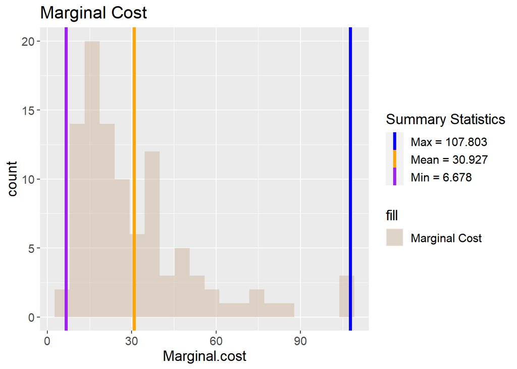

The Lerner index is showing there to be a significant percentage markup of prices above marginal costs for many of the models. This implies that there is a decent amount of market power in the market. However, this might be due to the model over estimating market power of the firms as it is assuming that all vehicles are equally substitutable which might lead to marginal cost estimates that are further from observed market prices. If we relax this assumption and say that a potential BMW purchaser is more likely to substitute to a Lexus than a Mazda we might get marginal cost estimates closer to the observed prices in the data set.

```r
#gen new ownership matrix
cars2004$mfrid.new <- cars2004$mfrid
cars2004$mfrid.new[which(cars2004$mfrid ==9)] <- 8
cars$mfrid.new <- cars$mfrid
cars$mfrid.new[which(cars$mfrid ==9)] <- 8
# gen new alpha with new ownership
IV.reg.2 <- ivreg(u ~ dpm + length + hpw + factor(year) + factor(mfrid.new) | price | IV.dpm + IV.length +IV.hpw, data = cars )
summary(IV.reg)
```

```
##
## Call:
## ivreg(formula = u ~ dpm + length + hpw + year + mfrid | price |
##     IV.dpm + IV.length + IV.hpw, data = cars)
##
## Residuals:
##     Min      1Q  Median      3Q     Max
## -4.9799 -1.0387  0.1348  1.1128  4.7276
##
## Coefficients:
##              Estimate Std. Error t value Pr(>|t|)
## (Intercept) -13.98643    1.84320  -7.588 5.58e-13 ***
## price        -0.15522    0.19819  -0.783 0.434212
## dpm         -37.00261   55.85995  -0.662 0.508281
## length        0.03936    0.01155   3.409 0.000753 ***
## hpw           0.03595    0.05918   0.607 0.544124
## year2003     -3.32108    0.46461  -7.148 8.61e-12 ***
## year2005     -1.81333    0.49415  -3.670 0.000294 ***
## year2006     -6.33954    0.41138 -15.410  < 2e-16 ***
## mfrid1        2.92389    2.23325   1.309 0.191589
## mfrid2        0.22249    1.19217   0.187 0.852099
## mfrid3        0.17009    0.85858   0.198 0.843118
## mfrid4        0.64484    0.49699   1.297 0.195600
## mfrid5        0.77462    0.64646   1.198 0.231898
## mfrid6        0.71668    0.53828   1.331 0.184199
## mfrid7        1.90840    1.88170   1.014 0.311421
## mfrid8        0.13535    0.66769   0.203 0.839514
## mfrid9       -1.35439    2.93131  -0.462 0.644432
## mfrid10       4.04391    3.73473   1.083 0.279893
## mfrid11       0.34920    0.56859   0.614 0.539646
## mfrid13       0.68757    0.52037   1.321 0.187544
##
## Diagnostic tests:
##                  df1 df2 statistic p-value
## Weak instruments   3 262     0.648   0.585
## Wu-Hausman         1 263     0.343   0.559
## Sargan             2  NA     3.610   0.165
##
## Residual standard error: 1.656 on 264 degrees of freedom
## Multiple R-Squared: 0.6007,  Adjusted R-squared: 0.572
## Wald test: 22.59 on 19 and 264 DF,  p-value: < 2.2e-16
```

```r
alpha.2 <- IV.reg.2$coefficients[2]



ownership.Matrix.2 <- matrix(0, nrow(cars2004), nrow(cars2004))

for (i in 1:nrow(cars2004)) {
  for (j in 1:nrow(cars2004)) {
    if (cars2004$mfrid.new[i]==cars2004$mfrid.new[j]) {
      ownership.Matrix.2[i,j]=1
    }
  }
}

Partial.matrix.2 <- matrix(0, nrow(cars2004), nrow(cars2004))
for (i in 1:nrow(cars2004)) {
  for (j in 1:nrow(cars2004)) {
    if (i==j) {
      Partial.matrix.2[i,j] <- alpha.2*cars2004$Marketshare[i]*(1- cars2004$Marketshare[i])
    } else{
      Partial.matrix.2[i,j] <- - alpha.2*cars2004$Marketshare[i]*cars2004$Marketshare[j]
    }
  }
}


#Calculate prices after merger

mul.2 <- ownership.Matrix.2 * Partial.matrix.2
mul.2.inverse <- solve(mul.2)
Price.After <- Marginal.cost - (mul.2.inverse %*% cars2004$Marketshare)

price_change<-data.frame(change=c(rep(0,100)),mfrid=cars2004$mfrid.new,mfrid.name=cars2004$mfrid_name)
price_change[,1]<-(Price.After-cars2004$price)/cars2004$price

delta_means<-data.frame(means=rep(0,13))
for(i in 1:13){
  delta_means[i,]<-mean(price_change[price_change$mfrid==i,1])
}

rownames(delta_means) <- c(1:13)
delta_means
```

```
##         means
## 1  0.02381199
## 2  0.04392377
## 3  0.04159348
## 4  0.05921180
## 5  0.06195173
## 6  0.04424083
## 7  0.01834390
## 8  0.03949584
## 9         NaN
## 10 0.01524890
## 11 0.06104036
## 12 0.04259185
## 13 0.03004470
```

We observe a price change increase between 1-6% for all firms. Notably, we see that although the firms a part of the merger increase prices by approximately 3.9%, they do not exhibit the highest price increase among all the firms. Hence the model does not display evidence that there is increased market power for the merged firms in comparison to the other firms in the market.

In general, the market seems less competitive, since the prices tend to increase.

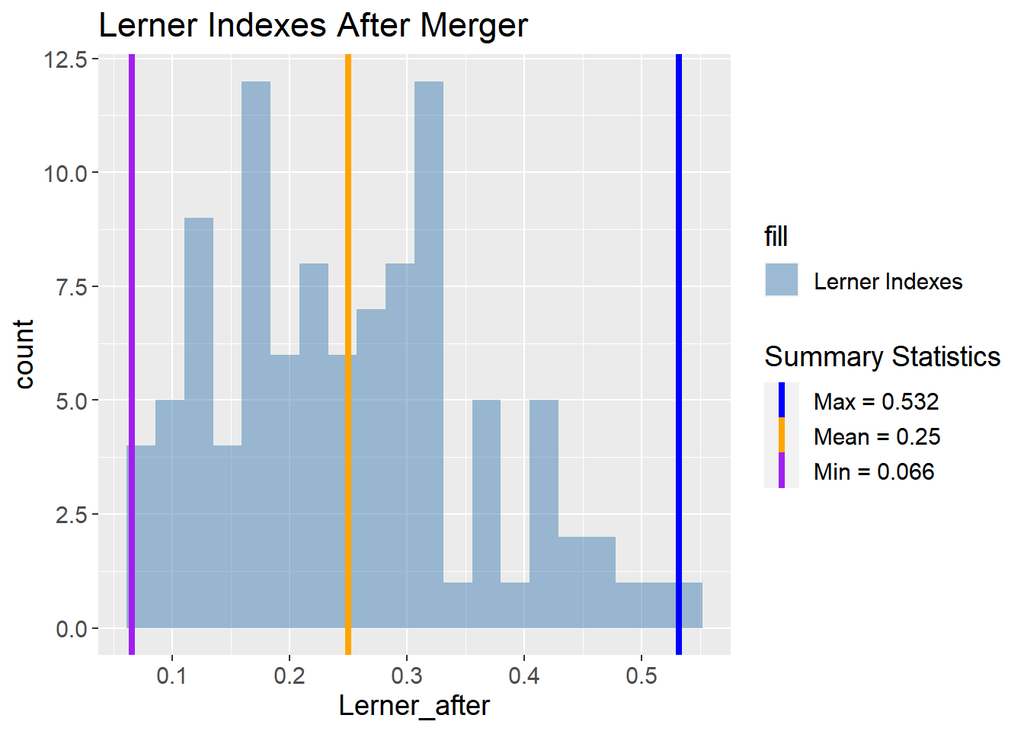

```r
Lerner.Index.after <- data.frame(Lerner_after=rep(0,100))
for (i in 1:100) {
  Lerner.Index.after[i,1] <- (Price.After[i,1] - Marginal.cost[i,1])/ Price.After[i,1]
}

Lerner_after <- data.frame(Lerner.Index.after)

# Plot the histogram with a red fill color
ggplot(Lerner_after, aes(Lerner_after, fill = "Lerner Indexes")) +
  geom_histogram(alpha = 0.5, position = "identity", bins = 20) +
  geom_vline(aes(xintercept = mean(Lerner_after), color = paste0("Mean = ",round(sum(Lerner_after)/100,3))),size=1.5)+
  geom_vline(aes(xintercept = max(Lerner_after), color = paste0("Max = ",round(max(Lerner_after),3))),size=1.5)+
  geom_vline(aes(xintercept = min(Lerner_after), color = paste0("Min = ",round(min(Lerner_after),3))),size=1.5)+
  scale_color_manual(values = c("blue", "orange","purple"), name = "Summary Statistics", labels = c(paste0("Max = ",round(max(Lerner_after),3)),paste0("Mean = ",round(sum(Lerner_after)/100,3)), paste0("Min = ",round(min(Lerner_after),3))))+
  scale_fill_manual(values = "steelblue")+
  ggtitle("Lerner Indexes After Merger")+
            theme(text=element_text(size = 14))
```

After the merger we see that the Lerner index values increase for a number of the vehicles.

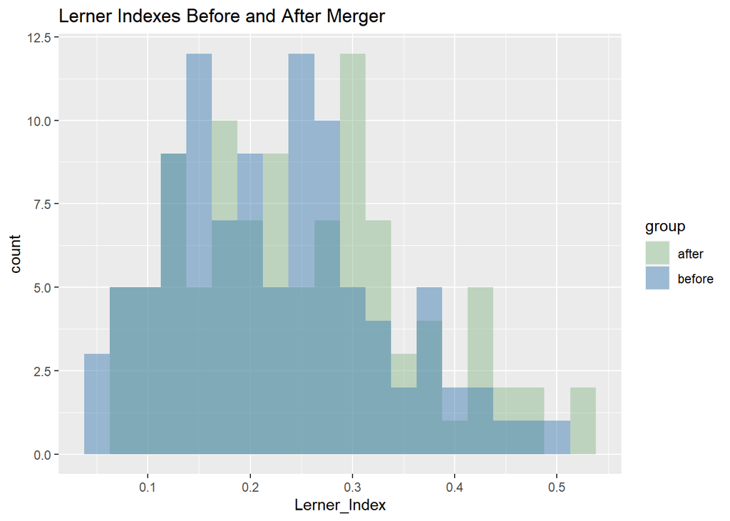

- need to calculate HHI index

```r
mf2_after<-0
for(i in 1:13){
mf1<-subset(cars2004, mfrid.new==i,select=c(Tvolume))
mf1<-(mf1/sum(cars2004$Tvolume))*100
mf2_after<-sum(mf1)^2+mf2_after
}
mf2_before<-0
for(i in 1:13){
mf1<-subset(cars2004, mfrid==i,select=c(Tvolume))
mf1<-(mf1/sum(cars2004$Tvolume))*100
mf2_before<-sum(mf1)^2+mf2_before
}

HHI<-data.frame(Before=mf2_before,After=mf2_after)
stargazer(HHI,type="html",title="HHI Before and After Merger",summary=FALSE)
```

**HHI Before and After Merger**

|  | Before | After |
| --- | --- | --- |
| 1 | 1,577.013 | 1,635.245 |

We can see that the market does become slightly more concentrated, however with such a small increase at this level of concentration the market authorities should not be concerned. An HHI Index below 2000 is generally not to be worried about.